# Replication of Demographic Imperative Project

Grace Tien and Jessamin Birdsall

May 12, 2015

The paper we have chosen to replicate is: “The Demographic Imperative in Religious Change in the United States,” written by Hout, Greeley, and Wilde (2001). The question that the authors are trying to answer is: Over the course of the last century, why has affiliation with “mainline” Protestantism declined, while affiliation with “conservative” Protestantism has increased in the United States? (Broadly speaking, “conservative” refers to more theologically conservative denominations and “mainline” refers to more liberal denominations.) To date, almost all sociological scholarship related to this question has assumed that mainline decline is the result of people converting/switching from mainline to conservative Protestantism. This paper argues that denominational switching actually accounts for *none* of the mainline decline. They argue that the most significant variable explaning mainline decline is *higher fertility* among conservative Protestants. In this paper, they use GSS data to test 4 hypotheses about the source of mainline decline: 1) higher fertility of conservative Protestants, 2) higher rate of mainline to conservative switching, 3) higher rate of apostasy among mainliners, 4) higher inflow of outsiders to conservative Protestant denominations. Looking at all cohorts born between 1900 and 1973, the authors develop demographic simulation models based on the variables of fertility, religious origins, and current religion. They then make counterfactual predictions in order to isolate the relative contributions of each of these variables to the observed decline in mainline affiliation.

```r
# Install packages and load libraries. Because we are working with the GSS Stata file (downloaded from the NORC website), we have to use the foreign package in order to read it in R. To read the excel files, we need the xlsx package.

library(dplyr)
```

```r
library(ggplot2)
library(broom)
library(stargazer)
library(xtable)
library(foreign)
library(xlsx)
library(gdata)
library(survey)
library(grid)
library(gridExtra)

# Open the file. Within the code, we insert convert.underscore = TRUE because R Stata uses underscores in variable names, but R does not.

GSS.df <- read.dta("GSS7214_R2.DTA", convert.factors = FALSE, convert.underscore=TRUE)

# Load data from Mike Hout (author). We load this file because it contains the data on denominational switching that we will need for some of the models.

hout.df <- read.xlsx("Scenarios1.xls", sheetName = "switching.within.prot")

# Select relevant variables. The variable names are taken directly from the GSS file. We are interested primarily in the variables of adult religious affiliation (relig), adult Protestant affiliation (fund), childhood Protestant affiliation (fund16), and total number of children born (childs) to the women in the sample. We filter out data collected after the year 1998, because the authors the used GSS data until 1998. Like the authors, we consider only women aged 25-74 who were born between 1903 and 1973.

# To handle the weights, we also include oversamp (to handle oversampling of the black population), formwt (to correct for errors in form randomization), wtssall (to deal with weights), sampcode (to handle sampling error), sample(related to sampling frame and method). We received guidance on handling GSS weights in R from Anthony Damico (code available in his github repo).

GSS.new.df <- GSS.df %>%
  select(cohort, age, sex, relig, relig16, fund, fund16, childs, year, oversamp, formwt, wtssall, sampcode, sample, adults) %>%
  arrange(desc(cohort)) %>%
  filter(year <= 1998, cohort >= 1903, cohort <= 1973, age >= 25, age <= 74)

# Remove missing data.

GSS1.df <- na.omit(GSS.new.df)

# Calculate the composite weight and recode the sample variable to manage black oversamples.

GSS1.df <-
  transform(
GSS1.df,
# The calculation for compwt comes from http://sda.berkeley.edu/D3/GSS10/Doc/gs100195.htm#COMPWT
compwt =  oversamp  *  formwt * wtssall * adults,
# The calculation for samplerc comes from http://sda.berkeley.edu/D3/GSS10/Doc/gs100195.htm#SAMPLERC
samplerc =
# If sample is a three or a four, samplerc should be a three
ifelse(sample %in% 3:4, 3,
# If sample is a six or a seven, samplerc should be a six
ifelse(sample %in% 6:7, 6,
# Otherwise, samplerc should just be set to sample
sample))
)

# Specify survey design
GSS.design <-
  svydesign(
~sampcode,
strata = ~samplerc,
data = subset(GSS1.df, !is.na(sampcode)) ,
weights = ~compwt,
nest = TRUE
)
```

*Figure 1: Fertility by Denominational Type*

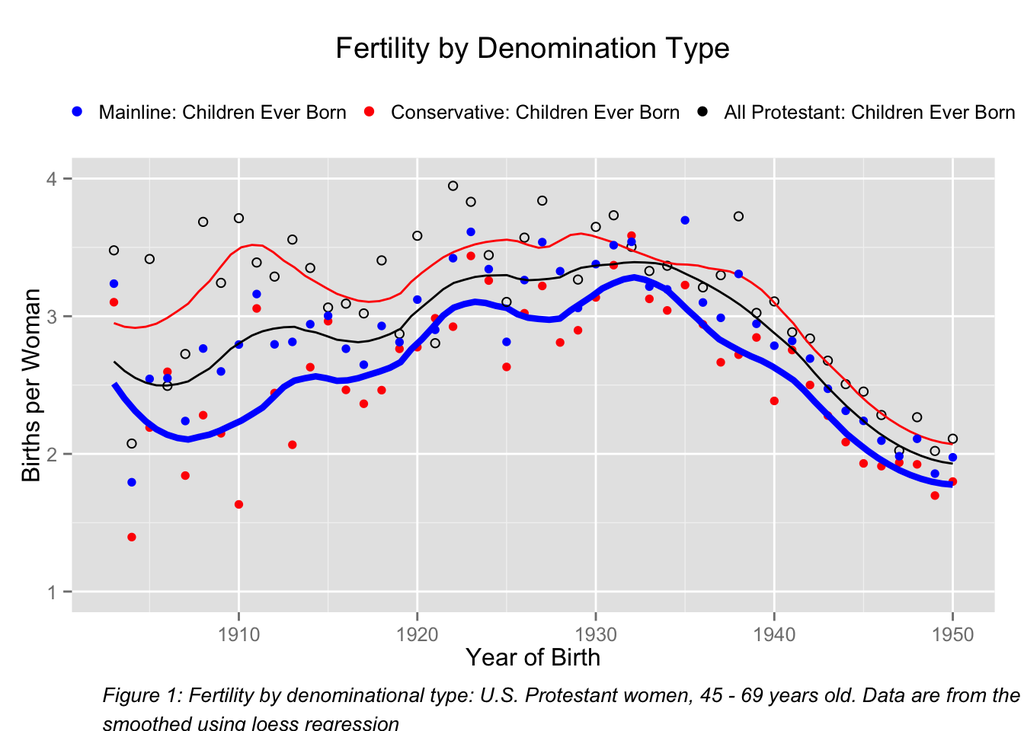

```r
# Replicate Figure 1. The first figure in the paper is a graph of fertility by denominational type (e.g. mainline and conservative). The x axis is year of birth (ranging from 1903 to 1950) and the y axis is births per woman.

# Recode denominations. Before we can do the calculations that go into this figure, we have to first recode the denominations from the GSS variables into values we can use. A person is considered mainline if s/he answered "Protestant" to the relig question and either "liberal" or "moderate" to the fund question. This is consistent with the authors' categorization, as best we can understand it.

GSS1.df$adult_main <- ifelse((GSS1.df$fund == 2 | GSS1.df$fund == 3) & GSS1.df$relig == 1, 1, 0)
adult_main <- GSS1.df$adult_main

GSS1.df$adult_cons <- ifelse((GSS1.df$fund == 1) & GSS1.df$relig == 1, 1, 0)
adult_cons <- GSS1.df$adult_cons

GSS1.df$adult_prot <- ifelse((GSS1.df$fund <=3 ) & GSS1.df$relig == 1, 1, 0)
adult_prot <- GSS1.df$adult_prot

# Subset the Protestant data.

prot_only <- GSS1.df %>%
  filter(adult_prot == 1)

# Specify the survey design for the Protestant subset.

GSS.design_prot <-
  svydesign(
    ~sampcode,
    strata = ~samplerc,
data = subset(prot_only, !is.na(sampcode)) ,
weights = ~compwt,
nest = TRUE
)

# Subset the mainline data.
main_only <- GSS1.df %>%
  filter(adult_main == 1)

# Specify survey design for the mainline subset.
GSS.design_main <-
  svydesign(
    ~sampcode,
strata = ~samplerc,
data = subset(main_only, !is.na(sampcode)) ,
weights = ~compwt,
nest = TRUE
)

# Subset the conservative data.
cons_only <- GSS1.df %>%
  filter(adult_cons == 1)

# Specify the survey design for the conservative subset.
GSS.design_cons <-
  svydesign(
    ~sampcode,
  strata = ~samplerc,
data = subset(cons_only, !is.na(sampcode)) ,
weights = ~compwt,
nest = TRUE
)

# Calculate the weighted mean number of children born to mainline women. Group by cohort.
mean_main_childs <- svyby(~childs, ~cohort, GSS.design_main, svymean)

# Calculate the weighted mean number of children born to conservative women. Group by cohort.
mean_cons_childs <- svyby(~childs, ~cohort, GSS.design_cons, svymean)

# Calculate the weighted mean number of children born to all Protestant women. Group by cohort.
mean_prot_childs <- svyby(~childs, ~cohort, GSS.design_prot, svymean)

# Plot. We got some inspiration for the annotation from Megan and Kalyani's code (thanks!).

fig1 <- ggplot(data = mean_prot_childs, aes(cohort, childs, color = "childs")) +
  geom_point(data =  mean_main_childs, aes(cohort, childs, color = "blue")) +
  geom_smooth(data = mean_main_childs, aes(cohort, childs, color = "blue"), size = 1.5, method = "loess", span = .3, se = FALSE, color = "blue") +
  ggtitle("Fertility by Denomination Type") +
  labs(x = "Year of Birth", y = "Births per Woman") +
  ylim(c(1, 4)) +
  xlim(c(1903, 1950)) +
  geom_point(data = mean_cons_childs, aes(cohort, childs, color = "red"), shape = 1) +
  geom_smooth(data = mean_cons_childs, aes(cohort, childs, color = "red"), method = "loess", span = .3, se = FALSE, color = "red") +
  geom_point(data = mean_prot_childs, aes(cohort, childs, color = "black")) +
  geom_smooth(data = mean_prot_childs, aes(cohort, childs, color = "black"), method = "loess", span = .3, se = FALSE, color = "black") +
  scale_colour_manual(values=c("blue", "red", "black"), labels=c("Mainline: Children Ever Born", "Conservative: Children Ever Born", "All Protestant: Children Ever Born")) +
  theme(legend.key = element_blank(),
        legend.title = element_blank(),
        legend.position = "top",
        legend.box = "horizontal") +
  guides(col = guide_legend()) +
  scale_linetype_manual(values = c(rep("solid", 3)))
fig1.note <- arrangeGrob(fig1,
        sub = textGrob("Figure 1: Fertility by denominational type: U.S. Protestant women, 45 - 69 years old. Data are from the GSS, 1973-98, \nsmoothed using loess regression",
        x = .1, hjust = 0, vjust = .5,
      gp = gpar(fontface = "italic", fontsize = 10)))
print(fig1.note)
```

*Figure 2: Proportion of Protestants professing a mainline denomination by year*

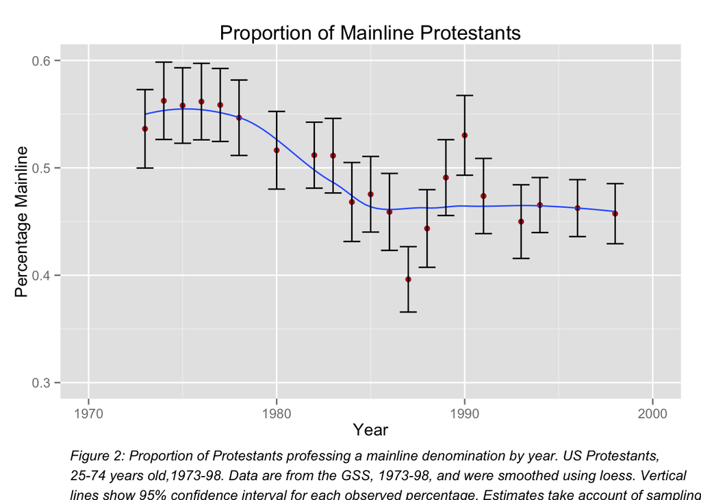

```r
# Replicate Figure 2. This figure shows the proportion of U.S. Protestants who identify as mainline by year in which the survey was taken. The x axis is year of survey (ranging from 1973 to 1998), and the y axis is proportion of Protestants professing a mainline affiliation.

# Although we were able to apply to survey weights to the mean values for Figure 1 (and later for the extension figure), we were not able to figure out how to apply survey weights to these calculations around proportions of the recoded categorical values.

main_prop <- GSS1.df  %>%
  group_by(year) %>%
  summarise(total.prot = sum(adult_prot), total.mainline= sum(adult_main)) %>%
  mutate(prop.main = total.mainline/total.prot)

# Create function to calculate confidence intervals

ci = function(main_prop) {
  se = main_prop$se <- sqrt((main_prop$prop.main * (1-main_prop$prop.main))/main_prop$total.prot)
lower <- main_prop$prop.main - 1.96 *se
upper <- main_prop$prop.main + 1.96 *se
cbind(lower, upper)
}

# Store confidence intervals
myCi <- ci(main_prop)

# Plot.

fig2 <- ggplot(data = main_prop, aes(x = year, y = prop.main)) + geom_point(color = "firebrick") + ggtitle("Proportion of Mainline Protestants") +
  labs(x = "Year", y = "Percentage Mainline") +
  ylim(c(0.3, 0.6)) +
  xlim(c(1970, 2000)) +
  geom_smooth(method = "loess", span = .8, se = F) +
  geom_errorbar(aes(x = year, ymin = myCi[,1], ymax = myCi[,2]), colour = "black")
fig2.note <- arrangeGrob(fig2,
      sub = textGrob("Figure 2: Proportion of Protestants professing a mainline denomination by year. US Protestants, \n25-74 years old,1973-98. Data are from the GSS, 1973-98, and were smoothed using loess. Vertical \nlines show 95% confidence interval for each observed percentage. Estimates take account of sampling design.",
        x = .1, hjust = 0, vjust = .5,
        gp = gpar(fontface = "italic", fontsize = 10)))
print(fig2.note)
```

*Figure 3: Proportion of Protestants Professing a Mainline Denomination of Year of Birth*

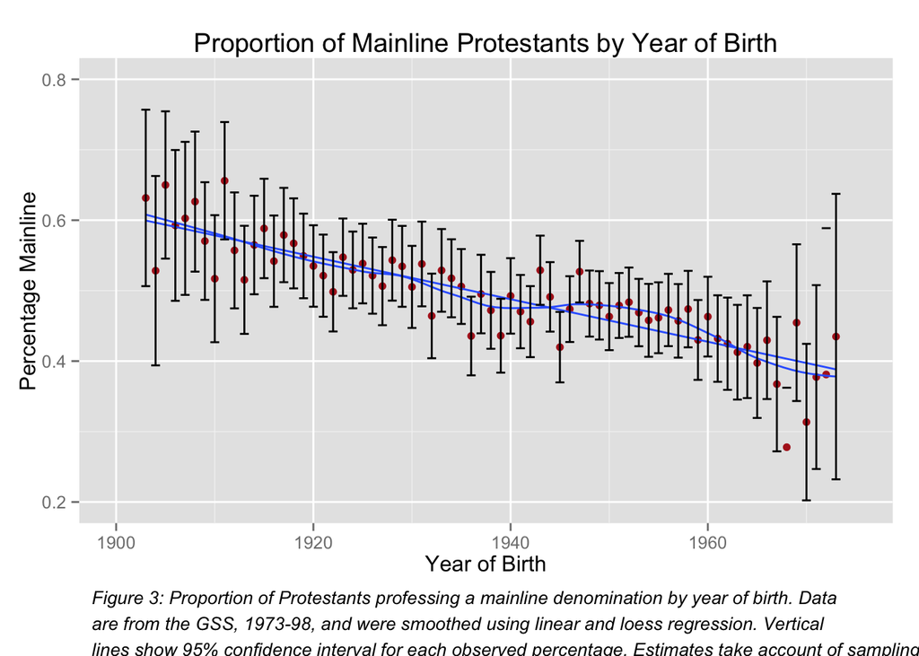

```r
# This figure shows the proportion of U.S. Protestants who identify as mainline by cohort. The x axis is year of birth (ranging from 1903 to 1973), and the y axis is proportion of Protestants professing a mainline affiliation.

# Calculate the proportion of mainline Protestants out of the total Protestants. Group by cohort.

main_prop_cohort <- GSS1.df  %>%
  group_by(cohort) %>%
  summarise(total.prot = sum(adult_prot), total.mainline= sum(adult_main)) %>%
  mutate(prop.main = total.mainline/total.prot)

# Calculate confidence intervals using function created earlier. Store values.

myCi2 <- ci(main_prop_cohort)

# Plot

fig3 <- ggplot(data = main_prop_cohort, aes(x = cohort, y = prop.main)) + geom_point(color = "firebrick") + ggtitle("Proportion of Mainline Protestants by Year of Birth") +
  labs(x = "Year of Birth", y = "Percentage Mainline") +
  ylim(c(0.2, 0.8)) +
  xlim(c(1900, 1975)) +
  geom_smooth(method = "lm", se = F) +
  geom_smooth(method = "loess", span = .4, se = F) +
  geom_errorbar(aes(x = cohort, ymin = myCi2[,1], ymax = myCi2[,2]), colour = "black")
fig3.note <- arrangeGrob(fig3,
      sub = textGrob("Figure 3: Proportion of Protestants professing a mainline denomination by year of birth. Data \nare from the GSS, 1973-98, and were smoothed using linear and loess regression. Vertical \nlines show 95% confidence interval for each observed percentage. Estimates take account of sampling design effects.",
        x = .1, hjust = 0, vjust = .5,
        gp = gpar(fontface = "italic", fontsize = 10)))
print(fig3.note)
```

*Figure 5: Observed Percentage of 25-74-year-old U.S. Protestants professing a mainline denomination and that predicted by switching between Protestant denominations by year of birth* (We have skipped Figure 4 because it incorporates a demographic model that we do not understand.)

```r
# The purpose of Figure 5 is to show the observed decline in mainline affiliation, and the predicted decline if we look only at switching. We draw upon the data stored in the hout.df because it is otherwise unclear how the authors generated switching from the raw data.

# Model 1: this will help us to predict the proportion of mainline affiliation by proportion of people who have switched from mainline to conservative. The authors use logistic regression.

model1 <- glm(prop.main ~ prop.switch.mtoc, data = hout.df)
stargazer(model1, type = "text")
```

```
##
## =============================================
##                       Dependent variable:
##                   ---------------------------
##                            prop.main
## ---------------------------------------------
## prop.switch.mtoc           -0.517**
##                             (0.210)
##
## Constant                   0.572***
##                             (0.028)
##
## ---------------------------------------------
## Observations                  75
## Log Likelihood              84.531
## Akaike Inf. Crit.          -165.061
## =============================================
## Note:             *p<0.1; **p<0.05; ***p<0.01
```

```r
# Model 2: this will help us to predict the proportion of mainline affiliation by proportion of people who have switched from conservative to mainline.

model2 <- glm(prop.main ~ prop.switch.ctom, data = hout.df)
stargazer(model2, type = "text")
```

```
##
## =============================================
##                       Dependent variable:
##                   ---------------------------
##                            prop.main
## ---------------------------------------------
## prop.switch.ctom           0.987***
##                             (0.101)
##
## Constant                   0.361***
##                             (0.016)
##
## ---------------------------------------------
## Observations                  75
## Log Likelihood              112.784
## Akaike Inf. Crit.          -221.567
## =============================================
## Note:             *p<0.1; **p<0.05; ***p<0.01
```

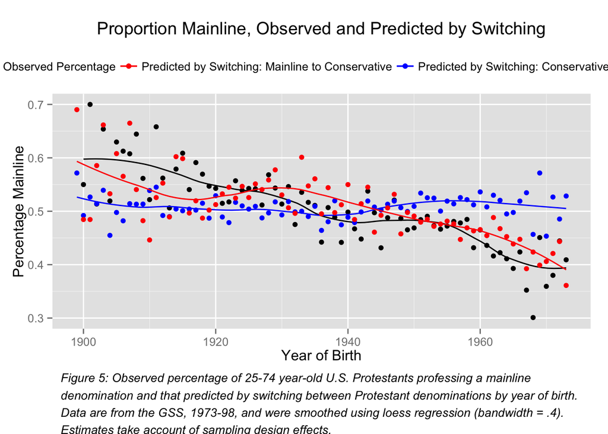

```r
# Calculate fitted values for Model 1

pred_prop1 <- predict(model1, type = "response", newdata = hout.df)
hout.df$pred_prop1 <- pred_prop1

# Calculate fitted values for Model 2

pred_prop2 <- predict(model2, type = "response", newdata = hout.df)
hout.df$pred_prop2 <- pred_prop2

# Plot observed and fitted values. Smooth using bandwidth of .4

fig5 <- ggplot(hout.df, aes(x = birth.year, y = prop.main)) +
  geom_point(aes(x = birth.year, y = prop.main, color = "black")) +
  geom_smooth(aes(y = prop.main, color = "black"), method = "loess", se = F, span = .4) +
  geom_point(aes(y = pred_prop1, color = "red")) +
  geom_smooth(aes(y = pred_prop1, color = "red"), method = "loess", se = F, span = .4) +
  geom_point(aes(y = pred_prop2, color = "blue")) +
  geom_smooth(aes(y = pred_prop2, color = "blue"), method = "loess", se = F, span = .4) +
  ylim(.3, .7) +
  ggtitle("Proportion Mainline, Observed and Predicted by Switching") +
  labs(x = "Year of Birth", y = "Percentage Mainline") +
    scale_colour_manual(values=c("black", "red", "blue"), labels=c("Observed Percentage", "Predicted by Switching: Mainline to Conservative", "Predicted by Switching: Conservative to Mainline")) +
  theme(legend.key = element_blank(),
        legend.title = element_blank(),
        legend.position = "top",
        legend.box = "horizontal") +
  guides(col = guide_legend()) +
  scale_linetype_manual(values = c(rep("solid", 3)))
fig5.note <- arrangeGrob(fig5,
      sub = textGrob("Figure 5: Observed percentage of 25-74 year-old U.S. Protestants professing a mainline \ndenomination and that predicted by switching between Protestant denominations by year of birth. \nData are from the GSS, 1973-98, and were smoothed using loess regression (bandwidth = .4). \nEstimates take account of sampling design effects.",
        x = .1, hjust = 0, vjust = .5,
        gp = gpar(fontface = "italic", fontsize = 10)))
print(fig5.note)
```

```r
# Our Model 1 predictions are in line with the authors' Model 1 predictions. However, our Model 2 predictions do not match the Model 2 predictions from the authors. We are not sure why this is the case. It may be related to the survey weights, which we were not able to fully apply.
```

*Table 1: Denominational Switching by Type of Origin Denomination*

```r
# As mentioned above, many social scientists and religious leaders have assumed that the phenonemon of switching (converting from one denomination to the other) is the primary explanatory variable behind the decline in mainline Protestant affiliation. The purpose of this table is to capture to what extent switching has happened across time, both within Protestantism and outside (to other religions or to no religion).

# Create new data frame with mutated variables that capture switching dynamics.

GSS2.df <- GSS1.df %>%
  select(cohort, relig, relig16, fund, fund16) %>% # Select variables of interest
  mutate(tb_period = ifelse(cohort >= 1900 & cohort <= 1909, "1900-9", "GSS2.df"), # Aggregate data into decades
       tb_period = ifelse(cohort >= 1910 & cohort <= 1919, "1910-19", tb_period),
       tb_period = ifelse(cohort >= 1920 & cohort <= 1929, "1920-29", tb_period),
       tb_period = ifelse(cohort >= 1930 & cohort <= 1939, "1930-39", tb_period),
       tb_period = ifelse(cohort >= 1940 & cohort <= 1940, "1940-49", tb_period),
       tb_period = ifelse(cohort >= 1950 & cohort <= 1959, "1950-59", tb_period),
       tb_period = ifelse(cohort >= 1960 & cohort <= 1973, "1960-73", tb_period)) %>%
  group_by(tb_period) %>%
  arrange(cohort) %>%
  mutate(adult_main = ifelse(fund == 2 | fund == 3 & relig == 1, 1, 0), # People who identify as mainline
    kid_main = ifelse(fund16 == 2 | fund16 == 3 & relig16 == 1, 1, 0), # People raised mainline
    adult_other = ifelse(fund >2 & relig == 2 | relig == 3 | relig == 5 | relig == 6 | relig == 7 | relig == 8 |   relig == 9 | relig == 10 | relig == 11 | relig == 12 | relig == 13, 1, 0), # People who identify with a non-Protestant religion
    adult_none = ifelse(relig == 4, 1, 0), # People who identify with no religion
        pm_same = sum(ifelse(adult_main == 1 & kid_main == 1, 1, 0))/sum(ifelse(kid_main == 1,1,0)), # Proportion of people raised mainline who remain mainline
         pm_otherprot = sum(ifelse(adult_main == 0 & kid_main == 1,1,0))/sum(ifelse(kid_main == 1,1,0)), # Proportion of people raised mainline who switched to conservative Protestantism.
         pm_otherrel = sum(ifelse(adult_other == 1 & kid_main == 1,1,0))/sum(ifelse(kid_main == 1,1,0)), # Proportion of people raised mainline who switched to another religion.
         pm_none = sum(ifelse(adult_none == 1 & kid_main == 1,1,0))/sum(ifelse(kid_main == 1,1,0)), # Proportion of people raised mainline who apostasized.
         pc_same = sum(ifelse(adult_main == 0 & kid_main == 0,1,0))/sum(ifelse(kid_main == 0,1,0)), # Proportion of people raised conservative who remain conservative
         pc_otherprot = sum(ifelse(adult_main == 1 & kid_main == 0,1,0))/sum(ifelse(kid_main == 0,1,0)), # Proportion of people raised conservative who switched to mainline Protestantism
         pc_otherrel = sum(ifelse(adult_other == 1 & kid_main == 0,1,0))/sum(ifelse(kid_main == 0,1,0)), # Proportion of people raised conservative who switched to another religion
         pc_none = sum(ifelse(adult_none == 1 & kid_main == 0,1,0))/sum(ifelse(kid_main == 0,1,0))) # Proportion of people raised conservative who apostasized

# Put in table format that aggregates into decades.

tb.1 <- GSS2.df %>%
  arrange(cohort) %>%
  group_by(tb_period) %>% # Group by decade
  summarise(mean_pm_same = round(mean(pm_same), 2), # Average proportions of each category for each decade
            mean_pm_otherprot = round(mean(pm_otherprot), 2),
            mean_pm_otherrel = round(mean(pm_otherrel), 2),
            mean_pm_none = round(mean(pm_none), 2),
            mean_pc_same = round(mean(pc_same), 2),
            mean_pc_otherprot = round(mean(pc_otherprot), 2),
            mean_pc_otherrel = round(mean(pc_otherrel), 2),
            mean_pc_none = round(mean(pc_none), 2))
colnames(tb.1) <- c("Decade", "Same as Origin (M)", "Other Protestant (M)", "Other Religion (M)", "No Religion (M)", "Same as Origin (C)", "Other Protestant (C)", "Other Religion (C)", "No Religion (C)")
tb.1
```

```
## Source: local data frame [8 x 9]
##
##    Decade Same as Origin (M) Other Protestant (M) Other Religion (M)
## 1  1900-9               0.87                 0.13               0.00
## 2 1910-19               0.88                 0.12               0.00
## 3 1920-29               0.87                 0.13               0.00
## 4 1930-39               0.84                 0.16               0.00
## 5 1940-49               0.82                 0.18               0.00
## 6 1950-59               0.81                 0.19               0.00
## 7 1960-73               0.81                 0.19               0.01
## 8 GSS2.df               0.82                 0.18               0.00
## Variables not shown: No Religion (M) (dbl), Same as Origin (C) (dbl),
##   Other Protestant (C) (dbl), Other Religion (C) (dbl), No Religion (C)
##   (dbl)
```

```r
# The percentages calculated above are similar to those in the paper but not exact. This may be related to the application of survey weights, or the amalgamation of variables, which the authors did not specifiy how in the paper how this was done.
```

*Table 2: Denominational Switching by Type of Current Denomination*

Table 2 is similar to Table 1, but in reverse. It shows, for people who currently identify as mainline, the proportions who identified as other Protestant, other religion, or no religion as a child. It then shows the same for people who currently identify as conservative.

```r
# Create new data frame with mutated variables that capture switching dynamics.

GSS3.df <- GSS1.df %>%
  select(cohort, relig, relig16, fund, fund16) %>%
  mutate(tb_period = ifelse(cohort >= 1900 & cohort <= 1909, "1900-9", "GSS3.df"),
       tb_period = ifelse(cohort >= 1910 & cohort <= 1919, "1910-19", tb_period),
       tb_period = ifelse(cohort >= 1920 & cohort <= 1929, "1920-29", tb_period),
       tb_period = ifelse(cohort >= 1930 & cohort <= 1939, "1930-39", tb_period),
       tb_period = ifelse(cohort >= 1940 & cohort <= 1940, "1940-49", tb_period),
       tb_period = ifelse(cohort >= 1950 & cohort <= 1959, "1950-59", tb_period),
       tb_period = ifelse(cohort >= 1960 & cohort <= 1973, "1960-73", tb_period)) %>%
  group_by(tb_period) %>%
  arrange(cohort) %>%
  mutate(adult_main = ifelse(fund == 2 | fund == 3 & relig == 1, 1, 0), # People who identify as mainlin
    adult_cons = ifelse(fund == 1 & relig == 1, 1, 0), # People who identify as conservative
    kid_cons = ifelse(fund16 == 1 & relig16 == 1, 1, 0), # People who were raised conservative
    kid_main = ifelse(fund16 == 2 | fund16 == 3 & relig16 == 1, 1, 0), # People who were raised conservative
    kid_other = ifelse(fund16 > 2 & relig16 == 2 | relig16 == 3 | relig16 == 5 | relig16 == 6 | relig16 == 7 | relig16 == 8 | relig16 == 9 | relig16 == 10 | relig16 == 11 | relig16 == 12 | relig16 == 13, 1, 0), # People who were raised in another religion
    kid_none = ifelse(fund16 >1 & relig16 == 4, 1, 0), # People who were raised in no religion
        pm_same = sum(ifelse(kid_main == 1 & adult_main == 1, 1, 0))/sum(ifelse(adult_main == 1,1,0)), # Proportion of mainliners who were also raised mainline
         pm_otherprot = sum(ifelse(kid_cons == 1 & adult_main == 1,1,0))/sum(ifelse(adult_main == 1,1,0)), # Proportion of mainliners who were raised conservative
         pm_otherrel = sum(ifelse(kid_other == 1 & adult_main == 1,1,0))/sum(ifelse(adult_main == 1,1,0)), # Proportion of mainliners who were raised in another religion
         pm_none = sum(ifelse(kid_none ==1 & adult_main == 1,1,0))/sum(ifelse(adult_main == 1,1,0)), # Proportion of mainliners who were raised in no religion
         pc_same = sum(ifelse(kid_cons == 1 & adult_cons == 1,1,0))/sum(ifelse(adult_cons == 1,1,0)), # Proportion of conservatives who were raised conservative
         pc_otherprot = sum(ifelse(kid_main == 1 & adult_cons == 1,1,0))/sum(ifelse(adult_cons == 1,1,0)), # Proportion of conservatives who were raised mainline
         pc_otherrel = sum(ifelse(kid_other == 1 & adult_cons == 1,1,0))/sum(ifelse(adult_cons == 1,1,0)), # Proportion of conservatives who were raised in another religion
         pc_none = sum(ifelse(kid_none == 1 & adult_cons == 1,1,0))/sum(ifelse(adult_cons == 1,1,0))) # Proportion of conservatives who were raised in no religion

# Put in table format that aggregates into decades

tb.2 <- GSS3.df %>%
 arrange(cohort) %>%
  group_by(tb_period) %>%
  summarise(mean_pm_same = round(mean(pm_same), 2), # Average proportions of each category for each decade
            mean_pm_otherprot = round(mean(pm_otherprot), 2),
            mean_pm_otherrel = round(mean(pm_otherrel), 2),
            mean_pm_none = round(mean(pm_none), 2),
            mean_pc_same = round(mean(pc_same), 2),
            mean_pc_otherprot = round(mean(pc_otherprot), 2),
            mean_pc_otherrel = round(mean(pc_otherrel), 2),
            mean_pc_none = round(mean(pc_none), 2))
colnames(tb.2) <- c("Decade", "Same as Current (M)", "Other Protestant (M)", "Other Religion (M)", "No Religion (M)", "Same as Current (C)", "Other Protestant (C)", "Other Religion (C)", "No Religion (C)")

tb.2
```

```
## Source: local data frame [8 x 9]
##
##    Decade Same as Current (M) Other Protestant (M) Other Religion (M)
## 1  1900-9                0.89                 0.10                  0
## 2 1910-19                0.90                 0.09                  0
## 3 1920-29                0.87                 0.11                  0
## 4 1930-39                0.86                 0.12                  0
## 5 1940-49                0.84                 0.14                  0
## 6 1950-59                0.90                 0.08                  0
## 7 1960-73                0.91                 0.07                  0
## 8 GSS3.df                0.88                 0.10                  0
## Variables not shown: No Religion (M) (dbl), Same as Current (C) (dbl),
##   Other Protestant (C) (dbl), Other Religion (C) (dbl), No Religion (C)
##   (dbl)
```

```r
# As is the case with Table 1, these percentages do not match up perfectly with those listed in the paper. This could be due to the application of survey weights and/or a difference in coding religious identification (e.g. their amalgamation of GSS variables to create the "other religion" category).
```

*Extension of Figure 1: Fertility by Denominational Type* This paper was published in 2001, and so the authors used GSS data up through 1998 to analyze trends in denominational affiliation and fertility. They looked at cohorts born between 1903 and 1973. We have the the GSS cumulative data through 2006, so we are curious to see how, if at all, trends in affiliation or fertility may have changed since 1998.

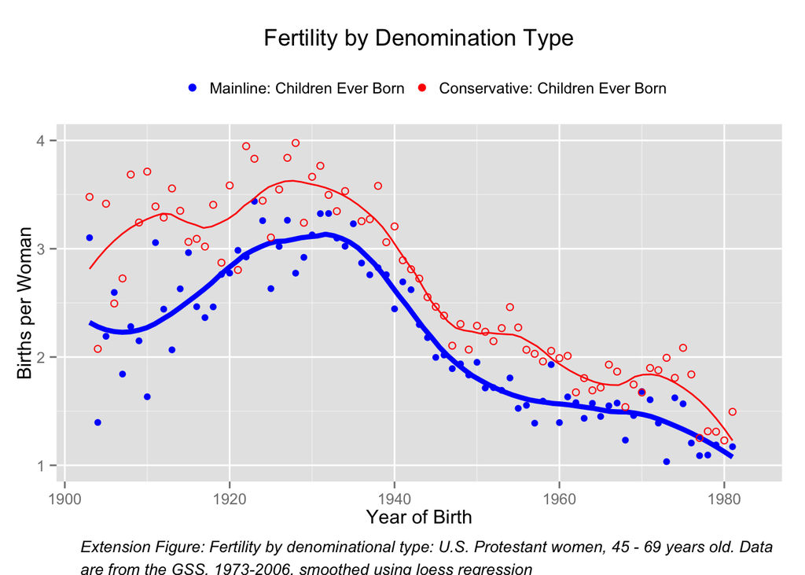

```r
# Create new dataframe with the cumulative data. Select relevant variables.

GSS.new.ext.df <- GSS.df %>%
  select(cohort, age, sex, relig, relig16, fund, fund16, childs, year, oversamp, formwt, wtssall, sampcode, sample, adults) %>%
  arrange(desc(cohort)) %>%
  filter(year, cohort >= 1903, cohort <= 1981, age >= 25, age <= 74)

# Remove missing data.
extended.df <- na.omit(GSS.new.ext.df)

# Calculate the composite weight and recode the sample variable to manage black oversamples.
extended.df <-
  transform(
  extended.df,
# The calculation for compwt comes from http://sda.berkeley.edu/D3/GSS10/Doc/gs100195.htm#COMPWT
compwt =  oversamp  *  formwt * wtssall * adults,
# The calculation for samplerc comes from http://sda.berkeley.edu/D3/GSS10/Doc/gs100195.htm#SAMPLERC
samplerc =
# If sample is a three or a four, samplerc should be a three
ifelse(sample %in% 3:4, 3,
# If sample is a six or a seven, samplerc should be a six
ifelse(sample %in% 6:7, 6,
# Otherwise, samplerc should just be set to sample
sample))
)

# Specify survey design
extended.design <- svydesign(~sampcode, strata = ~samplerc, data = subset(extended.df, !is.na(sampcode)), weights = ~compwt, nest = TRUE)

# Recode denominations.
extended.df$adult_main2 <- ifelse((extended.df$fund == 2 | extended.df$fund == 3) & extended.df$relig == 1, 1, 0)
adult_main2 <- extended.df$adult_main2

extended.df$adult_cons2 <- ifelse((extended.df$fund == 1) & extended.df$relig == 1, 1, 0)
adult_cons2 <- extended.df$adult_cons2

extended.df$adult_prot2 <- ifelse((extended.df$fund <=3 ) & extended.df$relig == 1, 1, 0)
adult_prot2 <- extended.df$adult_prot2

# Subset the Protestant data.
prot2_only <- extended.df %>%
  filter(adult_prot2 == 1)

# Specify the survey design for the Protestant subset.
extended.design_prot <-
  svydesign(
    ~sampcode,
    strata = ~samplerc,
  data = subset(prot2_only, !is.na(sampcode)) ,
weights = ~compwt,
nest = TRUE
)

# Subset the mainline data.
main2_only <- extended.df %>%
  filter(adult_main2 == 1)

# Specify survey design for the mainline subset.
extended.design_main <-
  svydesign(
    ~sampcode,
  strata = ~samplerc,
data = subset(main2_only, !is.na(sampcode)) ,
weights = ~compwt,
nest = TRUE
)

# Subset the conservative data.
cons2_only <- extended.df %>%
  filter(adult_cons2 == 1)

# Specify the survey design for the conservative subset.
extended.design_cons <-
  svydesign(
    ~sampcode,
  strata = ~samplerc,
data = subset(cons2_only, !is.na(sampcode)) ,
weights = ~compwt,
nest = TRUE
)

# Calculate the weighted mean number of children born to mainline women. Group by cohort.
mean_main_childs2 <- svyby(~childs, ~cohort, extended.design_main, svymean)

# Calculate the weighted mean number of children born to conservative women. Group by cohort.
mean_cons_childs2 <- svyby(~childs, ~cohort, extended.design_cons, svymean)

# Calculate the weighted mean number of children born to all Protestant women. Group by cohort.
mean_prot_childs2 <- svyby(~childs, ~cohort, extended.design_prot, svymean)

# Plot.
ext1 <- ggplot() +
  geom_point(data = mean_main_childs2, aes(cohort, childs, color = "blue")) +
  geom_smooth(data = mean_main_childs2, aes(cohort, childs, color = "blue"), size = 1.5, method = "loess", span = .3, se = FALSE, color = "blue") +
  ggtitle("Fertility by Denomination Type") +
  labs(x = "Year of Birth", y = "Births per Woman") +
  ylim(c(1, 4)) +
  xlim(c(1903, 1983)) +
  geom_point(data = mean_cons_childs2, aes(cohort, childs, color = "red"), shape = 1) +
  geom_smooth(data = mean_cons_childs2, aes(cohort, childs, color = "red"), method = "loess", span = .3, se = FALSE, color = "red") +
  scale_colour_manual(values=c("blue", "red"), labels=c("Mainline: Children Ever Born", "Conservative: Children Ever Born", "All Protestant: Children Ever Born")) +
  theme(legend.key = element_blank(),
        legend.title = element_blank(),
        legend.position = "top",
        legend.box = "horizontal") +
  guides(col = guide_legend()) +
  scale_linetype_manual(values = c(rep("solid", 3)))
ext1.note <- arrangeGrob(ext1,
        sub = textGrob("Extension Figure: Fertility by denominational type: U.S. Protestant women, 45 - 69 years old. Data \nare from the GSS, 1973-2006, smoothed using loess regression",
        x = .1, hjust = 0, vjust = .5,
        gp = gpar(fontface = "italic", fontsize = 10)))
print(ext1.note)
```

When we add in 8 more years of data and 8 more cohorts, we see that fertility has continued to decline for both mainline and conservative Protestants. Between 1973 and 1980, the slope of decline for conservatives appears to be steeper than that of mainlines, which suggests that perhaps conservative fertility rates may intersect with mainline fertility rates within the next decade. This would be an interesting phenomenon to investigate further in the future, as we have several hypotheses about why fertility rates between the two denominations may be converging (e.g. rising levels of education among conservatives, later age of marriage for conservative women).